```r
library(tidyverse)
```

Домашнее задание сдается на почту в виде двух файлов, Rmd и html (или в виде тетрадки, если вы выполняли задание в колабе). Чтобы облегчить проверку домашнего задания, мы просим вас писать код в блоки для кода на R, например,

```r
# YOUR CODE HERE
# (do not forget to remove #'s and all this text so that we could run the code)
```

и текст в блоки для текста. Пожалуйста, впишите ниже ваше имя и фамилию:

```
     Ксения Артамонова
```

Перед сдачей домашнего задания рекомендуем запустить `Run All` или сгенерировать html-страницу с помощью `Knit`, чтобы убедиться, что в финальной версии весь ваш код будет запускаться без проблем. Дисклеймер - в зависимости от среды, в которой вы выполняете задания, округление непрерывных значений может производиться несколько по-разному. В заданиях ниже не будут оцениваться расхождения с образцом в количестве знаков после запятой в выдаче. Аналогично, несколько иначе могут выглядеть шрифты в таблицах и графиках, на такие расхождения тоже не стоит обращать внимания, если нет специального требования в задании. И не стесняйтесь задавать вопросы по домашнему заданию в телеграм-группе.

## 1. Универсальные лингвические иерархии: порядок прилагательных в новогреческом языке (стандартный и кипрский диалекты)

Данные (социолингвистическая анкета и результаты эксперимента) взяты, с адаптацией, из исследования: Leivada, Evelina; Westergaard, Marit, 2019, [Universal linguistic hierarchies are not innately wired](https://www.ncbi.nlm.nih.gov/pmc/articles/PMC6679903/pdf/peerj-07-7438.pdf). PeerJ, v.7.

Источник данных: репозиторий TROLLing: Leivada, Evelina; Westergaard, Marit, 2019, “Replication Data for: Universal linguistic hierarchies are not innately wired”, https://doi.org/10.18710/NTLLUF, DataverseNO, V1

#### Конструкции с двумя прилагательными

В английском языке порядок двух прилагательных в таких фразах, как:

```
 a big black bag # хорошо
*a black big bag # неприемлемо, грамматически неправильно или семантически аномально
```

определяется семантическим классом прилагательного (например, прилагательное «цвета» ближе к существительному, чем прилагательное «размера»).

Синтаксическая иерархия близости к существительному в универсальной грамматике Хомского предполагает следующий порядок, который считается врожденным и универсальным (= действительным для всех языков).

```
Subjective Comment > Evidential > Size > Length
> Height > Speed > Depth > Width > Temperature > Wetness > Age
> Shape > Color > Nationality/Origin > Material
# (на основе Scott, 2002: 114)
```

Цель исследования Leivada & Westergaard — определить, что происходит, когда люди воспринимают примеры с порядком, который либо соответствует иерархии, либо нарушает ее.

#### Метод

В первом эксперименте 140 нейротипичных взрослых носителей языка выполнили задание с выбором на время (a timed forced choice task), в котором использовались стимулы, представляющие комбинацию двух прилагательных и конкретного существительного (например, *Έπια ένα στενό ισπανικό βρασιόλι.* ‘I bought a narrow Spanish bracelet.’). Были собраны данные двух типов:

1. суждения о приемлемости по 3-балльной шкале Ликерта:
   1. неправильно,
   2. ни правильно, ни неправильно,
   3. правильный;
2. время реакции (RT).

В стимулах использовались три условия:  
1. прилагательное размера > прилагательное национальности, 2. прилагательное цвета > прилагательное формы,  
3. прилагательное субъективного комментария > прилагательное материала.

Каждое условие предъявлялось в двух вариантах порядка слов. При конгруэнтном порядке расположение пары прилагательных соответствовало тому, что диктует универсальная иерархия. В неконгруэнтном порядке порядок был обратным, поэтому иерархия была нарушена.

Во втором эксперименте 30 билингвов (носителей стандартного и кипрского греческого) были протестированы на обоих диалектах, по 36 наблюдений на участника, по 18 на каждый вариант.

В обоих экспериментах использовались два типа [филлеров] (https://www.hlp.rochester.edu/resources/BCS152-Tutorial/Fillers.html): FillerAcceptable и FillerUnacceptable — предложения, которые включали правильно построенные и неграмматические структуры, соответственно. В обеих задачах соотношение наполнителей к реальным тестовым структурам составляло 2:1. Смотри также [ключи к данным](https://www.ncbi.nlm.nih.gov/pmc/articles/PMC6679903/bin/peerj-07-7438-s001.txt).

#### Данные

Загрузите данные из [файла](https://raw.githubusercontent.com/olesar/2025dav4compling/refs/heads/main/data/greek-word-order-mono-acceptability-coded-rt.txt%22) в переменную `mono`, переведя строковые данные в факторы. В переменной `mono_socio` сохраните данные социолингвистической [анкеты](https://raw.githubusercontent.com/olesar/2025dav4compling/refs/heads/main/data/greek-word-order-mono_socio.txt), также переведя строковые данные в факторы.

```r
library(tidyverse)

mono_url <- "https://raw.githubusercontent.com/olesar/2025dav4compling/refs/heads/main/data/greek-word-order-mono-acceptability-coded-rt.txt"

mono <- read.table(
  file = mono_url,
  header = TRUE,
  sep = ";",
  stringsAsFactors = FALSE,
  quote = "",
  comment.char = "",
  na.strings = c("NA", ""),
  fileEncoding = "UTF-8"
)

mono <- mono %>%
  mutate(
    ParticipantID = factor(ParticipantID),
    TypeOfQuestion = factor(TypeOfQuestion),
    TypeOfStimuli = factor(TypeOfStimuli),
    WordOrder = factor(WordOrder),
    ResponseAcceptabilityJudgement = factor(
      ResponseAcceptabilityJudgement,
      levels = c("Wrong", "Neither", "Correct"),
      ordered = TRUE),
    RT = as.numeric(RT))

socio_url <- "https://raw.githubusercontent.com/olesar/2025dav4compling/refs/heads/main/data/greek-word-order-mono_socio.txt"

mono_socio_raw <- read.table(
  file = socio_url,
  header = TRUE,
  sep = ";",
  stringsAsFactors = FALSE,
  quote = "",
  comment.char = "",
  na.strings = c("NA", ""))

mono_socio <- mono_socio_raw %>%
  mutate(
    ParticipantID = factor(ParticipantID),
    TypeOfQuestion = factor(TypeOfQuestion),
    QuestionCategory = factor(QuestionCategory),
    Responce = factor(Responce)) %>%
  pivot_wider(
    id_cols = ParticipantID,
    names_from = QuestionCategory,
    values_from = Responce) %>%
  rename(
    sex = sex,
    education = education,
    handedness = handedness,
    age = age,
    country1 = country1,
    country2 = country2) %>%
  mutate(
    sex = factor(sex),
    education = factor(education),
    handedness = factor(handedness),
    country1 = factor(country1),
    country2 = factor(country2),
    age = as.numeric(as.character(age)))
```

```r
mono
```

[output not shown]

[output cut: 22668 more lines]

```r
mono_socio
```

```
## # A tibble: 30 × 7
##    ParticipantID                age country1 country2 education handedness sex
##    <fct>                      <dbl> <fct>    <fct>    <fct>     <fct>      <fct>
##  1 2bc93481d25426f259a0f1a3d…    58 Nicosia  Kaimakl… College   right      fema…
##  2 4b4c9debd4aedeb1fd3dfc9f1…    24 Nicosia  Nicosia  Universi… right      male
##  3 5cfee92572d81db494f803686…    33 Nicosia  Nicosia  Postgrad… right      fema…
##  4 6a0bfef2c1607be61fa9879d3…    36 Paphos   Nicosia  Postgrad… right      male
##  5 9c334b8c45452362a37cb790b…    23 Limassol Limassol Postgrad… right      fema…
##  6 9eed449d848443290afdb9aca…    27 Limasso… Limassol Universi… right      fema…
##  7 21dd0d72f74143f083e088410…    46 Nicosia  Moscow   Postgrad… right      male
##  8 25c1b946d47b93d059a223201…    34 Limassol Limassol Universi… right      male
##  9 79b886b6ef0a5213abc3cc590…    32 Nicosia  Nicosia  Postgrad… right      fema…
## 10 85b0e3c5d7dcaf0e1faa81dfe…    24 Nicosia  Nicosia  Universi… right      male
## # ℹ 20 more rows
```

## Описание данных

### 1.1

Взглянем на данные `mono_socio`, чтобы ответить на следующие вопросы о социолингвистических характеристиках испытуемых:

1. Сколько участников указано в датафрейме?
2. Сколько из них женщин и мужчин?
3. Какие уровни образования указаны в датафрейме?
4. Сколько участников каждого уровня образования?
5. Сколько леворуких и праворуких участников?

Напишите код, представляющий ответы на эти вопросы в виде одной или нескольких таблиц. Используйте функции из пакета tidyverse: `filter`, `group_by`, `count` and `distinct`. (Еще один способ - использовать `pivot_wider`.)

```r
# Сколько участников указано в датафрейме?
n_participants <- mono_socio %>%
  distinct(ParticipantID) %>%
  count() %>%
  pull(n)

n_participants
```

```
## [1] 30
```

```r
# Сколько из них женщин и мужчин?
gender_table <- mono_socio %>%
  filter(!is.na(sex)) %>%
  count(sex, name = "Число_участников") %>%
  rename(Пол = sex)

gender_table
```

```
## # A tibble: 2 × 2
##   Пол    Число_участников
##   <fct>             <int>
## 1 female               19
## 2 male                 11
```

```r
#  Какие уровни образования указаны в датафрейме?
education_levels <- mono_socio %>%
  filter(!is.na(education)) %>%
  distinct(education) %>%
  pull(education)

education_levels
```

```
## [1] College          UniversityDegree Postgraduate     PhDongoing
## Levels: College PhDongoing Postgraduate UniversityDegree
```

```r
# Сколько участников каждого уровня образования?
education_table <- mono_socio %>%
  filter(!is.na(education)) %>%
  count(education, name = "Число_участников") %>%
  arrange(desc(Число_участников)) %>%
  rename(Образование = education)

education_table
```

```
## # A tibble: 4 × 2
##   Образование      Число_участников
##   <fct>                       <int>
## 1 Postgraduate                   14
## 2 UniversityDegree               12
## 3 College                         3
## 4 PhDongoing                      1
```

```r
# Сколько леворуких и праворуких участников?
handedness_table <- mono_socio %>%
  filter(!is.na(handedness)) %>%
  count(handedness, name = "Число_участников") %>%
  rename(Доминантная_рука = handedness)

handedness_table
```

```
## # A tibble: 2 × 2
##   Доминантная_рука Число_участников
##   <fct>                       <int>
## 1 left                            2
## 2 right                          28
```

### 1.2

Сравните полученную информацию с данными из таблицы 1 в [статье](https://pmc.ncbi.nlm.nih.gov/articles/PMC6679903/pdf/peerj-07-7438.pdf). Можно ли сказать, что данные, которые вы загрузили по ссылке, позволяют воспроизвести результаты этого исследования?

```
В целом, да, воспроизвести можно, тк выборка такая же, распределение по полу совпадает, общая структура данных совпадает.
```

### 1.3

Постройте график плотности, который показывает распределение RT в эксперименте в целом (для всех участников и условий. Отобразите красным пунктиром линию, показывающую среднее значение RT.

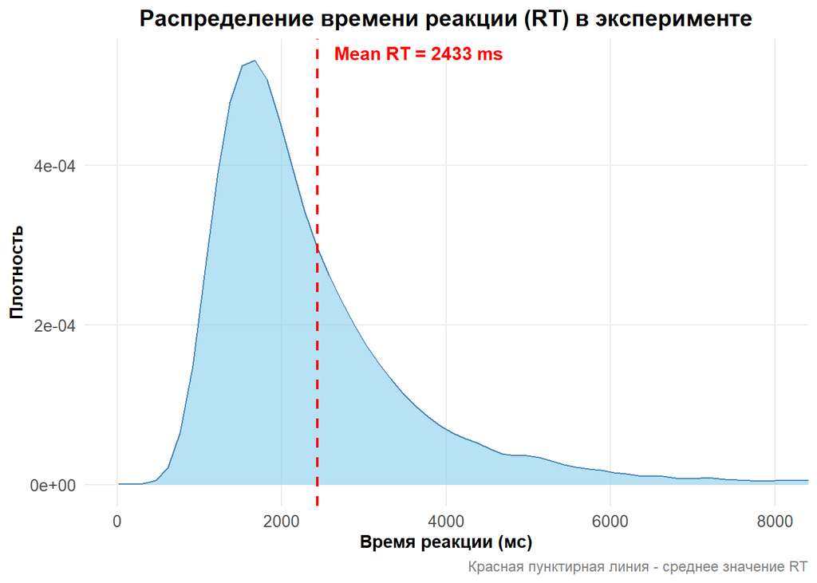

```r
library(ggplot2)

mono_clean <- mono %>%
  filter(!is.na(RT))

mean_rt <- mean(mono_clean$RT, na.rm = TRUE)

rt_density_plot <- ggplot(mono_clean, aes(x = RT)) +
  geom_density(
    fill = "skyblue",
    color = "steelblue",
    alpha = 0.6) +
  geom_vline(
    xintercept = mean_rt,
    color = "red",
    linetype = "dashed",
    linewidth = 0.8) +
  annotate("text",
    x = mean_rt,
    y = Inf,
    label = paste("Mean RT =", round(mean_rt), "ms"),
    vjust = 1.5,           # вертикальное выравнивание
    hjust = -0.1,          # горизонтальное выравнивание
    color = "red",
    fontface = "bold",
    size = 4) +
  labs(
    title = "Распределение времени реакции (RT) в эксперименте",
    x = "Время реакции (мс)",
    y = "Плотность",
    caption = "Красная пунктирная линия - среднее значение RT") +
  theme_minimal() +
  theme(
    plot.title = element_text(face = "bold", size = 14, hjust = 0.5),
    plot.subtitle = element_text(size = 11, hjust = 0.5, color = "gray40"),
    plot.caption = element_text(size = 9, color = "gray50"),
    axis.title = element_text(face = "bold"),
    axis.text = element_text(size = 10),
    panel.grid.minor = element_blank()) +
  coord_cartesian(xlim = c(0, 8000))

rt_density_plot
```

### 1.4

Верно ли, что данные времени реакции нормально распределены? Есть ли в распределении длинные левые или правые хвосты??

[output not shown]

### 1.5

Преобразуйте данные с помощью функциии логарифма (RTlog = log10(RT)).

```r
mono_clean_lg <- mono %>%
  filter(!is.na(RT), RT > 0) %>%
  mutate(
    RT_log = log10(RT))

mean_rt_log <- mean(mono_clean_lg$RT_log, na.rm = TRUE)
geo_mean_rt <- 10^mean_rt_log
```

### 1.6

Создайте график, похожий на 1.3, но показывающий логарифимированные значения RT.

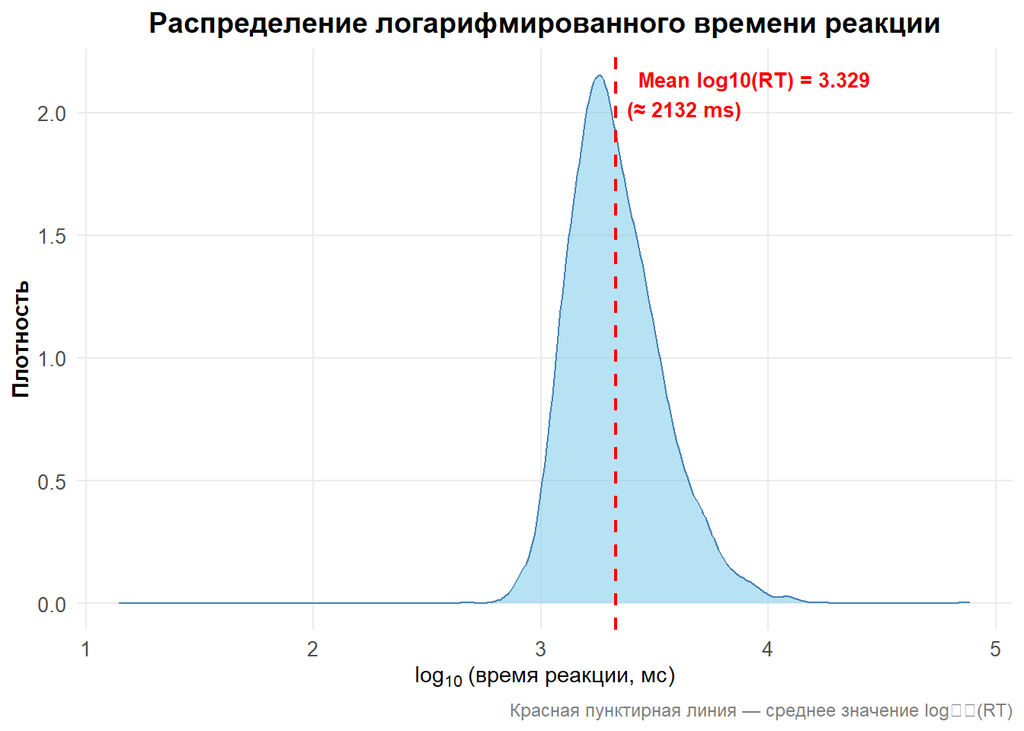

```r
rt_log_density_plot <- ggplot(mono_clean_lg, aes(x = RT_log)) +
  geom_density(
    fill = "skyblue",
    color = "steelblue",
    alpha = 0.6) +
  geom_vline(
    xintercept = mean_rt_log,
    color = "red",
    linetype = "dashed",
    linewidth = 0.8) +
  annotate(
    "text",
    x = mean_rt_log,
    y = Inf,
    label = paste0("Mean log10(RT) = ", round(mean_rt_log, 3),
                   "\n(≈ ", round(geo_mean_rt), " ms)"),
    vjust = 1.5,
    hjust = -0.1,
    color = "red",
    fontface = "bold",
    size = 3.5) +
  labs(
    title = "Распределение логарифмированного времени реакции",
    x = expression(log[10]~"(время реакции, мс)"),
    y = "Плотность",
    caption = "Красная пунктирная линия — среднее значение log₁₀(RT)") +
  theme_minimal() +
  theme(
    plot.title = element_text(face = "bold", size = 14, hjust = 0.5),
    plot.subtitle = element_text(size = 11, hjust = 0.5, color = "gray40"),
    plot.caption = element_text(size = 9, color = "gray50"),
    axis.title = element_text(face = "bold"),
    axis.text = element_text(size = 10),
    panel.grid.minor = element_blank())

rt_log_density_plot
```

### 1.7

Отфильтруйте выбросы:  
* автоматические ответы, время реакции на которые меньше 600 ms (будем полагать, что кнопка была нажата слишком быстро, еще до того, как у участника было достаточно времени рассмотреть показанный ему стимул и принять решение);  
* ответы, в которых RTlog отличается от среднего значения RTlog более, чем на 3 стандартных отклонения (SD);  
* филлеры (как приемлемые, так и неприемлемые).  
Сохраните очищенные от выбросов данные в переменную `mono1`.

```r
mono1 <- mono %>%
  filter(!is.na(RT), RT > 0) %>%
  mutate(RT_log = log10(RT)) %>%
  filter(RT >= 600) %>%
  filter(!TypeOfStimuli %in% c("FillerAcceptable", "FillerUnacceptable"))

rt_log_mean <- mean(mono1$RT_log, na.rm = TRUE)
rt_log_sd <- sd(mono1$RT_log, na.rm = TRUE)

mono1 <- mono1 %>%
  filter(
    RT_log >= (rt_log_mean - 3 * rt_log_sd),
    RT_log <= (rt_log_mean + 3 * rt_log_sd))

mono1
```

[output not shown]

[output cut: 7494 more lines]